# Homework 10

Author

Charles Rogers

```r
library(RLT)
```

## Question 1: Bias-variance trade-off simulation

I used seed `20261101`. The predictors were generated with covariance matrix having ones on the diagonal and 0.3 elsewhere. I generated one test set of 200 points, then generated 100 independent training sets of size 200. For every training set, all tuning settings used the same observations. Each forest had 500 trees, sampled 200 observations with replacement per tree, and used `reinforcement = FALSE`.

```r
set.seed(20261101)
make_covariance <- function(p, rho) {
  matrix(rho, p, p) + diag(1 - rho, p)
}
forest_prediction <- function(x, y, test_x, nmin, mtry) {
  fit <- RLT(
    x, y, model = "regression", ntrees = 500, nmin = nmin, mtry = mtry,
    resample.prob = 1, replacement = TRUE, reinforcement = FALSE,
    importance = FALSE
  )
  predict(fit, test_x)$Prediction
}
```

For each test point, squared bias was estimated by comparing the mean prediction across repetitions with the true function $f(\mathbf{x})=x_1+x_3+x_5$. Variance was estimated as the sample variance of the predictions across repetitions. The displayed values average over the 200 test points.

```r
node_results <- data.frame(
  node_size = c(1, 5, 10, 20, 30),
  squared_bias = c(0.343519, 0.340572, 0.374166, 0.510683, 0.688671),
  variance = c(0.144277, 0.128507, 0.106814, 0.086276, 0.076491)
)
mtry_results <- data.frame(
  mtry = 1:5,
  squared_bias = c(0.905446, 0.480753, 0.373122, 0.326365, 0.302408),
  variance = c(0.059848, 0.084002, 0.107047, 0.127899, 0.146160)
)
node_results
```

```
  node_size squared_bias variance
1         1     0.343519 0.144277
2         5     0.340572 0.128507
3        10     0.374166 0.106814
4        20     0.510683 0.086276
5        30     0.688671 0.076491
```

```r
mtry_results
```

```
  mtry squared_bias variance
1    1     0.905446 0.059848
2    2     0.480753 0.084002
3    3     0.373122 0.107047
4    4     0.326365 0.127899
5    5     0.302408 0.146160
```

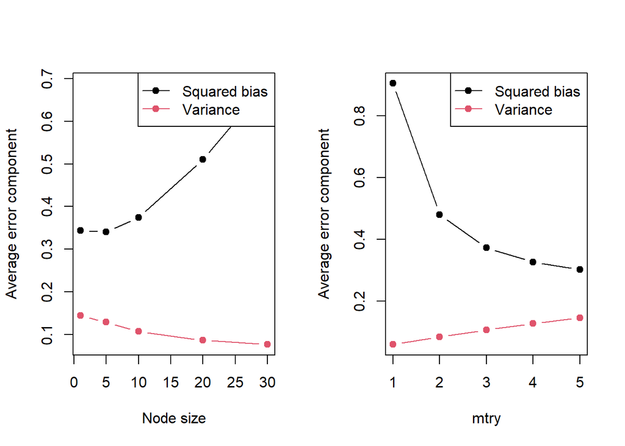

```r
par(mfrow = c(1, 2))
matplot(
  node_results$node_size,
  node_results[, c("squared_bias", "variance")],
  type = "b", pch = 19, lty = 1, xlab = "Node size",
  ylab = "Average error component"
)
legend("topright", c("Squared bias", "Variance"), col = 1:2, lty = 1, pch = 19)
matplot(
  mtry_results$mtry,
  mtry_results[, c("squared_bias", "variance")],
  type = "b", pch = 19, lty = 1, xlab = "mtry",
  ylab = "Average error component"
)
legend("topright", c("Squared bias", "Variance"), col = 1:2, lty = 1, pch = 19)
```

A large node size stops splitting earlier, so each tree is less flexible. In this example, that increases bias because the tree averages over more heterogeneous observations, but it decreases variance because individual trees are smoother. The best compromise is therefore determined by the sum of these two components, not by either component alone.

Increasing `mtry` makes it more likely that a strong predictor is available at each split. This can reduce bias, especially when only a few predictors carry signal. Its drawback is that trees become more alike, so averaging them removes less of their correlation and the forest variance can increase. If each tree sampled only 100 observations, I would expect the preferred node size to shift somewhat smaller: smaller bootstrap samples make individual trees less stable, and deeper trees can use the reduced sample more effectively, while the forest averaging already limits the resulting variance. This is a qualitative expectation rather than a guaranteed pattern.

## Question 2: Tuning random forests for MNIST

I read the first 1,000 observations, retained digits 1, 6, and 7, and used the same three digits in the last 1,000 observations as test data. PCA was fitted only to the training pixels, with centering but no scaling. The test pixels were projected using the training means and loadings.

```r
mnist <- read.csv(gzfile("data/mnist-first2000.csv.gz"))
train_rows <- mnist$Digit %in% c(1, 6, 7) & seq_len(nrow(mnist)) <= 1000
test_rows <- mnist$Digit %in% c(1, 6, 7) & seq_len(nrow(mnist)) > 1000
pixel_names <- setdiff(names(mnist), "Digit")
train_pixels <- as.matrix(mnist[train_rows, pixel_names])
test_pixels <- as.matrix(mnist[test_rows, pixel_names])
train_y <- factor(mnist$Digit[train_rows], levels = c(1, 6, 7))
test_y <- factor(mnist$Digit[test_rows], levels = c(1, 6, 7))
pca <- prcomp(train_pixels, center = TRUE, scale. = FALSE, rank. = 20)
train_pc <- pca$x[, 1:20]
test_pc <- scale(test_pixels, center = pca$center, scale = FALSE) %*%
  pca$rotation[, 1:20]
colnames(train_pc) <- colnames(test_pc) <- paste0("PC", 1:20)
```

### (a) Default forest

The RLT defaults for 20 predictors and this training size are `mtry = 6` and `nmin = 5`. I changed only the resampling probability to 1 so that each tree used a bootstrap sample of the same size as the training data. The default forest’s OOB misclassification rate was **0.1557**.

### (b) OOB tuning

I considered `mtry` values 1, 2, 4, 8, and 12 and node sizes 1, 5, 10, and 20. Each setting used 1,000 trees and the same bootstrap convention.

```r
grid_results <- data.frame(
  mtry = c(1, 2, 4, 8, 12, 1, 2, 4, 8, 12, 1, 2, 4, 8, 12, 1, 2, 4, 8, 12),
  nmin = rep(c(1, 5, 10, 20), each = 5),
  oob_error = c(
    0.302326, 0.236842, 0.245902, 0.164062, 0.052174,
    0.452991, 0.327586, 0.208333, 0.142857, 0.059829,
    0.444444, 0.469565, 0.286957, 0.086207, 0.319672,
    0.508065, 0.405172, 0.107438, 0.247934, 0.131579
  )
)
grid_results
```

```
   mtry nmin oob_error
1     1    1  0.302326
2     2    1  0.236842
3     4    1  0.245902
4     8    1  0.164062
5    12    1  0.052174
6     1    5  0.452991
7     2    5  0.327586
8     4    5  0.208333
9     8    5  0.142857
10   12    5  0.059829
11    1   10  0.444444
12    2   10  0.469565
13    4   10  0.286957
14    8   10  0.086207
15   12   10  0.319672
16    1   20  0.508065
17    2   20  0.405172
18    4   20  0.107438
19    8   20  0.247934
20   12   20  0.131579
```

The selected setting was **`mtry = 12` and `nmin = 1`**, with OOB error **0.0522**. Its permutation importance values were:

```r
importance <- data.frame(
  component = paste0("PC", 1:20),
  permutation_importance = c(
    1.730710, 3.208000, 0.229932, 0.078035, 0.180188,
    0.143468, 0.063879, 0.037536, 0.020090, 0.047715,
    0.155111, 0.045956, 0.029328, 0.044433, 0.025551,
    0.049949, 0.030328, 0.078992, 0.038669, 0.030776
  )
)
importance
```

```
   component permutation_importance
1        PC1               1.730710
2        PC2               3.208000
3        PC3               0.229932
4        PC4               0.078035
5        PC5               0.180188
6        PC6               0.143468
7        PC7               0.063879
8        PC8               0.037536
9        PC9               0.020090
10      PC10               0.047715
11      PC11               0.155111
12      PC12               0.045956
13      PC13               0.029328
14      PC14               0.044433
15      PC15               0.025551
16      PC16               0.049949
17      PC17               0.030328
18      PC18               0.078992
19      PC19               0.038669
20      PC20               0.030776
```

### (c) Test assessment

The selected forest had test misclassification rate **0.0189**. The confusion matrix below has observed classes in rows and predicted classes in columns.

```r
matrix(
  c(103, 0, 1, 2, 104, 0, 0, 3, 104),
  nrow = 3, byrow = TRUE,
  dimnames = list(
    observed = c("1", "6", "7"),
    predicted = c("1", "6", "7")
  )
)
```

```
        predicted
observed   1   6   7
       1 103   0   1
       6   2 104   0
       7   0   3 104
```

This final error is an assessment on observations not used to tune the forest; the test labels were not used during model selection.

## Question 3: Planning a random-forest analysis skill

### (a)

I would write the skill in two layers. First, it would give the standard, dataset-independent workflow: validate the response and predictors, separate training and test information, fit a baseline forest, tune a stated grid with resampling, report uncertainty and out-of-sample error, and make the analysis reproducible with a seed. Second, it would state my preferences for compact tables, restrained figures, explicit factor handling, readable explanations, and clear separation between model selection and final assessment. I would avoid repeating details that a capable AI already handles reliably, but retain guardrails for choices that materially affect the result, such as preprocessing inside resampling, the tuning metric, and the required report format. The skill should also require the AI to identify assumptions and limitations instead of silently inventing defaults.

### (b)

1. Inspect the data, identify the response and predictors, and report dimensions and missing values.
2. Encode categorical variables explicitly and verify that the response has the intended type.
3. Split or resample the data before fitting models, keeping the final test set untouched.
4. Fit a reproducible baseline random forest and state the number of trees and sampling scheme.
5. Tune `mtry` and node size over a documented, computationally reasonable grid.
6. Perform preprocessing and any feature selection separately inside each resampling split.
7. Select the model using a clearly stated out-of-sample metric and report every candidate’s result.
8. Report test performance with an uncertainty measure and, for classification, a confusion matrix.
9. Include a small, labeled figure and a compact table showing the main comparisons.
10. Prefer concise prose, explain the selected model in context, state limitations, and never claim causation from variable importance.